# Photon Diffusion in Gray Matter

W. Bauer

01/22/2015

#### Estimating optical properties of gray matter at 900 nm

Referring to the previous note, Optical Properties of Tissue, a rough reduced scattering coefficient estimate in gray matter is $\mu_s' \approx 10\: cm^{-1}$ and a rough anisotropy coefficient estimate is $g \approx .9$. Since $g = 1-\frac{\mu_s'}{\mu_s}$ these imply a scattering coefficient of$\mu_s = \frac{\mu_s'}{1-g} = 100\: cm^{-1}$i.e., 100 scattering events per cm, hence an average distance of .1 mm traveled between scattering events.

In the previous note absorption is given by a formula involving volume fractions of various constituents such as water. Assume vasculature accounts for around 5% of gray matter volume, equally apportioned between oxygenated and deoxgenated blood, and assume a fractional volume of 80% water as per a reference given in the previous note. Assume other chromophores are negligible. At 900 nm, $\mu_{a.oxy} \approx 6.5 \: cm^{-1}$, $\mu_{a.deoxy} \approx 4.5 \: cm^{-1}$, and $\mu_{a.water} \approx 0.076 \: cm^{-1}.$ Then$\mu_{a.gray} \approx 0.05 \left(0.5 \cdot 6.5 + 0.5 \cdot 4.5 \right) + 0.8 \cdot 0.076 = 0.336 \: cm^{-1}.$

#### Typical photon tracks

Consider an infinite planar section of gray matter 3 mm thick, with photons at 900 nm wavelength originating in a 3mm column at the origin of the xy plane. The following figure shows typical paths. Both absorption and scattering are taken into account but neither reflection at boundaries nor re-entry from surrounding tissues is considered.

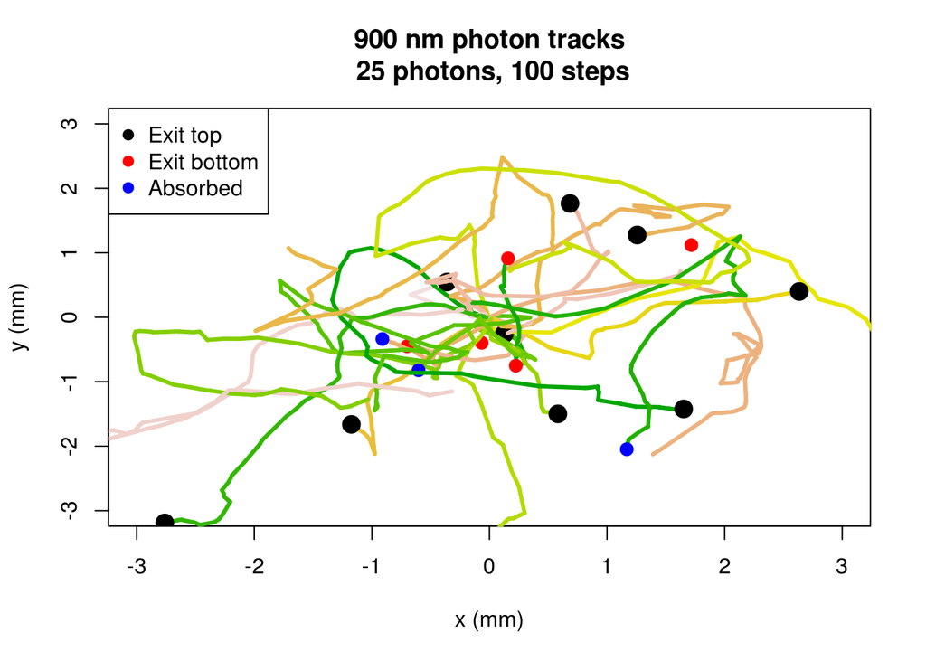

#### Propagation with scattering and absorption in an infinite medium

In planar section of finite thickness, as above, boundary effects are complicating factors. In an infinitely thick medium, scattering alone even with significant anisotropy, should amount to a random walk in three dimensions. As such, photons emitted from the same origin should diffuse in a Gaussian pattern. If the photons are emitted in random directions at their source, the Gaussian pattern should be spherical (not elliptical.) Absorption will reduce the number of photons which survive but should not alter the general pattern.

Using the above optical characteristics in an infinite medium, 1000 photons were tracked for 100 steps each as a quick test. (A step constitutes an event, either absorption or scattering.) A Shapiro-Wilk normality test applied to the x, y, and z, coordinates of surviving photons fails to reject normality. The coordinates of surviving photons have Gaussian distributions as expected.

```
##   Shapiro_Wilk_p_value
## x            0.8293792
## y            0.8957136
## z            0.2204761
```

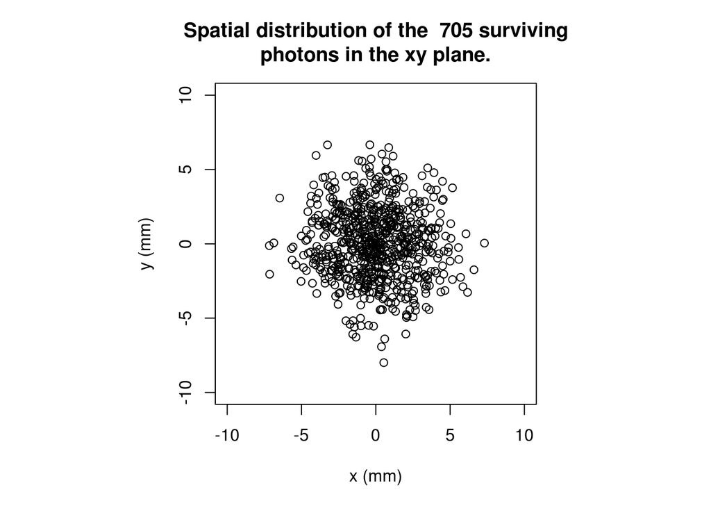